## Geostatistical prediction

Linear predictors:
$$\hat{Z}(s_0) = \sum_{i=1}^n \lambda_i Z(s_i)$$

Precition weights are such that the prediction error $\hat{Z}(s_0)-Z(s_0)$ has expectation zero and minimal variance; this involves inverting the covariance matrix of $Z=\{Z(s_1),...,Z(s_n)\}$.

## Demo case:

### Model variogram:

```r
library(sf)
demo(meuse_sf, ask = FALSE)
```

```
##
##
##  demo(meuse_sf)
##  ---- ~~~~~~~~
##
## > data(meuse, package = "sp") # load data.frame from sp
##
## > library(sf)
##
## > meuse_sf = st_as_sf(meuse, coords = c("x", "y"), crs = 28992)
##
## > meuse_sf[1:5,]
## Simple feature collection with 5 features and 12 fields
## geometry type:  POINT
## dimension:      XY
## bbox:           xmin: 181025 ymin: 333330 xmax: 181307 ymax: 333611
## epsg (SRID):    28992
## proj4string:    +proj=sterea +lat_0=52.15616055555555 +lon_0=5.38763888888889 +k=0.9999079 +x_0=155000 +y_0=463000 +ellps=bessel +towgs84=565.2369,50.0087,465.658,-0.406857,0.350733,-1.87035,4.0812 +units=m +no_defs
##   cadmium copper lead zinc  elev       dist   om ffreq soil lime landuse
## 1    11.7     85  299 1022 7.909 0.00135803 13.6     1    1    1      Ah
## 2     8.6     81  277 1141 6.983 0.01222430 14.0     1    1    1      Ah
## 3     6.5     68  199  640 7.800 0.10302900 13.0     1    1    1      Ah
## 4     2.6     81  116  257 7.655 0.19009400  8.0     1    2    0      Ga
## 5     2.8     48  117  269 7.480 0.27709000  8.7     1    2    0      Ah
##   dist.m              geometry
## 1     50 POINT (181072 333611)
## 2     30 POINT (181025 333558)
## 3    150 POINT (181165 333537)
## 4    270 POINT (181298 333484)
## 5    380 POINT (181307 333330)
##
## > summary(meuse_sf[1:5,])
##     cadmium          copper          lead            zinc
##  Min.   : 2.60   Min.   :48.0   Min.   :116.0   Min.   : 257.0
##  1st Qu.: 2.80   1st Qu.:68.0   1st Qu.:117.0   1st Qu.: 269.0
##  Median : 6.50   Median :81.0   Median :199.0   Median : 640.0
##  Mean   : 6.44   Mean   :72.6   Mean   :201.6   Mean   : 665.8
##  3rd Qu.: 8.60   3rd Qu.:81.0   3rd Qu.:277.0   3rd Qu.:1022.0
##  Max.   :11.70   Max.   :85.0   Max.   :299.0   Max.   :1141.0
##
##       elev            dist                om        ffreq soil  lime
##  Min.   :6.983   Min.   :0.001358   Min.   : 8.00   1:5   1:3   0:2
##  1st Qu.:7.480   1st Qu.:0.012224   1st Qu.: 8.70   2:0   2:2   1:3
##  Median :7.655   Median :0.103029   Median :13.00   3:0   3:0
##  Mean   :7.565   Mean   :0.116759   Mean   :11.46
##  3rd Qu.:7.800   3rd Qu.:0.190094   3rd Qu.:13.60
##  Max.   :7.909   Max.   :0.277090   Max.   :14.00
##
##     landuse      dist.m             geometry
##  Ah     :4   Min.   : 30   POINT        :5
##  Ga     :1   1st Qu.: 50   epsg:28992   :0
##  Aa     :0   Median :150   +proj=ster...:0
##  Ab     :0   Mean   :176
##  Ag     :0   3rd Qu.:270
##  Am     :0   Max.   :380
##  (Other):0
```

```r
library(gstat)
```

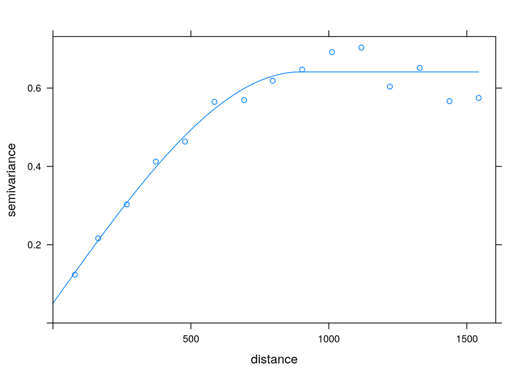

```r
v = variogram(log(zinc)~1, meuse_sf)
v.fit = fit.variogram(v, vgm(1, "Sph", 900, 1))
plot(v, v.fit)
```

```r
demo(meuse, package = "sp")
```

```
##
##
##  demo(meuse)
##  ---- ~~~~~
##
## > require(sp)
```

```
##
## > crs = CRS("+init=epsg:28992")
##
## > data("meuse")
##
## > coordinates(meuse) <- ~x+y
##
## > proj4string(meuse) <- crs
##
## > data("meuse.grid")
##
## > coordinates(meuse.grid) <- ~x+y
##
## > gridded(meuse.grid) <- TRUE
##
## > proj4string(meuse.grid) <- crs
##
## > data("meuse.riv")
##
## > meuse.riv <- SpatialPolygons(list(Polygons(list(Polygon(meuse.riv)),"meuse.riv")))
##
## > proj4string(meuse.riv) <- crs
##
## > data("meuse.area")
##
## > meuse.area = SpatialPolygons(list(Polygons(list(Polygon(meuse.area)), "area")))
##
## > proj4string(meuse.area) <- crs
```

```r
library(stars)
meuse_grid = st_as_stars(meuse.grid)
```

### Use in prediction:

```r
k = krige(log(zinc)~1, meuse_sf, meuse_grid, v.fit)
```

```
## [using ordinary kriging]
```

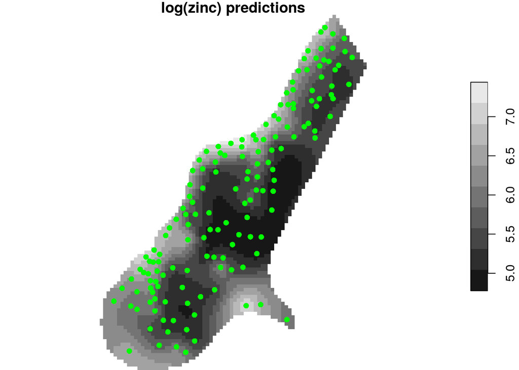

```r
plot(k["var1.pred"], main = "log(zinc) predictions", breaks = "equal", reset = FALSE)
plot(meuse_sf, add = TRUE, col = 'green', pch = 16)
```

### How to create a prediction grid like `meuse_grid` from scratch?

E.g. from a polygon, e.g. a shapefile read by `rgdal::readOGR`. Here, we’ll start with `meuse.area`

```r
data(meuse.area, package = "sp")
head(meuse.area) # the points of a polygon
```

```
##           x      y
## [1,] 180640 330080
## [2,] 180640 330120
## [3,] 180600 330120
## [4,] 180600 330160
## [5,] 180560 330160
## [6,] 180520 330160
```

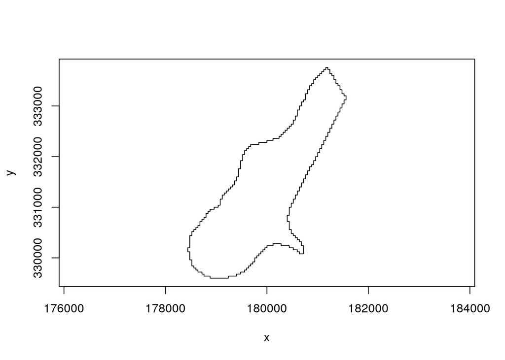

```r
plot(meuse.area, type = 'l', asp = 1)
```

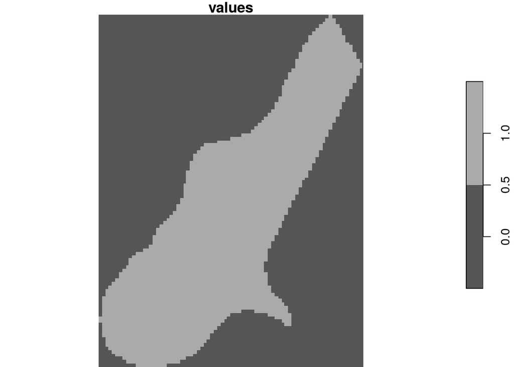

```r
x = st_as_stars(st_sfc(st_polygon(list(meuse.area))))
plot(x)
```

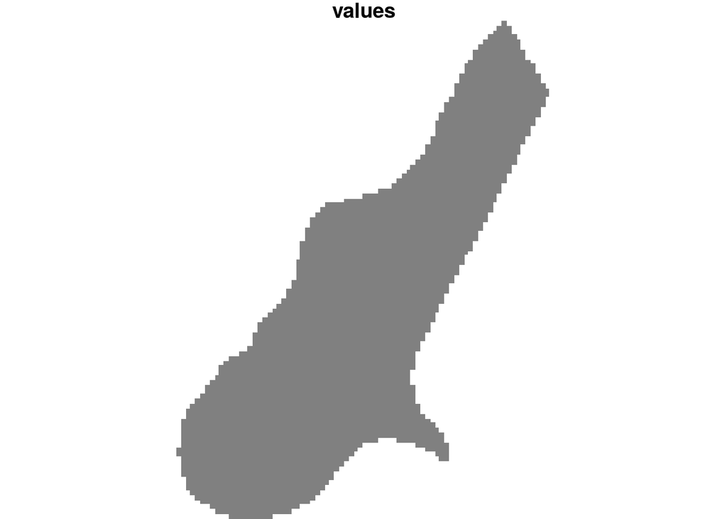

```r
x[x==0]=NA
plot(x)
```

## Next:

read all vignettes of the gstat package except for vignette ``prs’’:

```r
vignette(package = "gstat")
vignette("gstat")
```

Try to run the code yourself with

```r
edit(vignette("gstat"))
```

and copy-and-paste.

## Exercises

E1. Import one of the pm10 trajectories from http://pebesma.staff.ifgi.de/pm10/ using `read.csv`

```r
pm = read.csv("http://pebesma.staff.ifgi.de/pm10/3_1a.txt")
```

E2. Load package `sf` and use `st_as_sf` to convert this into an `sf` object, using argument `coords`; pay attention to the order of coordinates, and set `crs=4326` to specify longlat

```r
library(sf)
pm.sf = st_as_sf(pm, coords = c("Long", "Lat"), crs = 4326)
```

E3. Convert to EPSG 32632 (UTM zone 32N), using `st_transform`

```r
pm.sf_utm = st_transform(pm.sf, 32632)
```

E4. Load package `gstat` and compute a variogram of the pm10 variable, with maximum distance 300 m

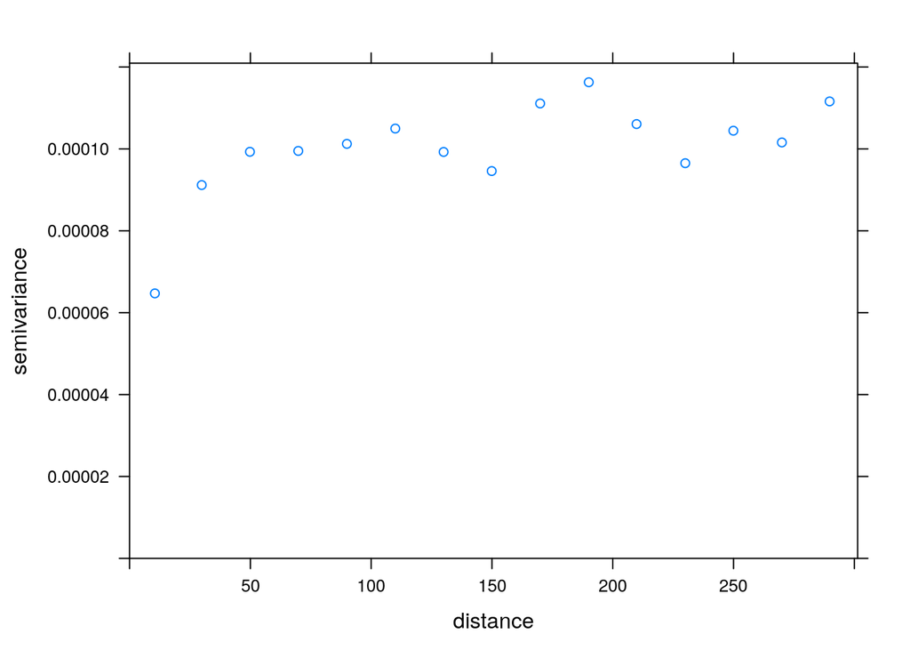

```r
library(gstat)
v = variogram(pm10 ~ 1, pm.sf_utm, cutoff = 300)
plot(v)
```

E5. Fit a variogram model to this, using `vgm(1, "Exp", 100, 1))` as the initial fit; save the fitted model

```r
v.fit = fit.variogram(v, vgm(1, "Exp", 100, 1))
v.fit
```

```
##   model        psill    range
## 1   Nug 3.009169e-05  0.00000
## 2   Exp 7.232491e-05 16.09521
```

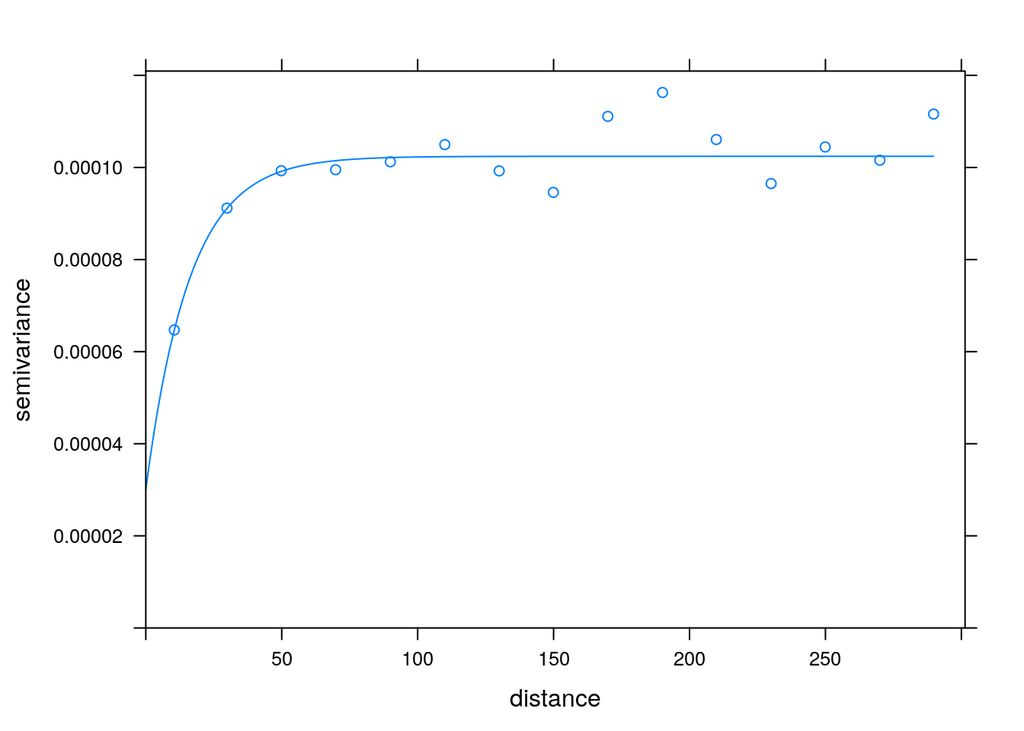

```r
plot(v, v.fit)
```

E6. Load package `stars` and compute a regular grid over the area, by first converting the `st_bbox` of your data to an `sfc` polygon using `st_as_sfc`, and then `st_as_stars` of that polygon.

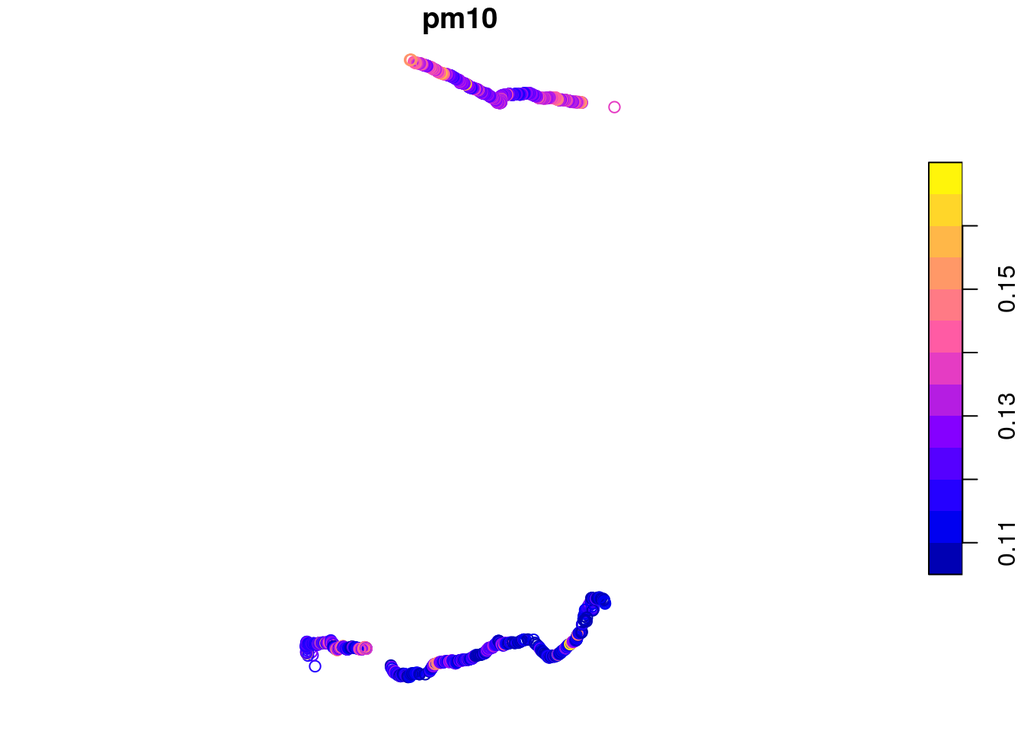

```r
plot(pm.sf_utm["pm10"])
```

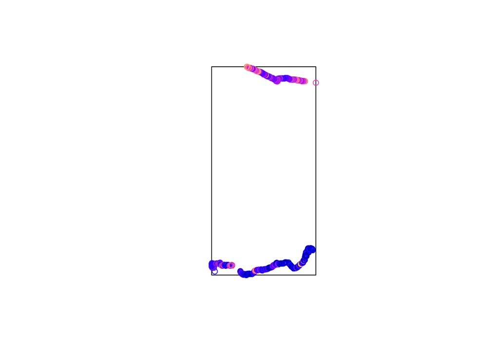

```r
pol = st_as_sfc(st_bbox(pm.sf_utm))
plot(pol)
plot(pm.sf_utm["pm10"], add = TRUE)
```

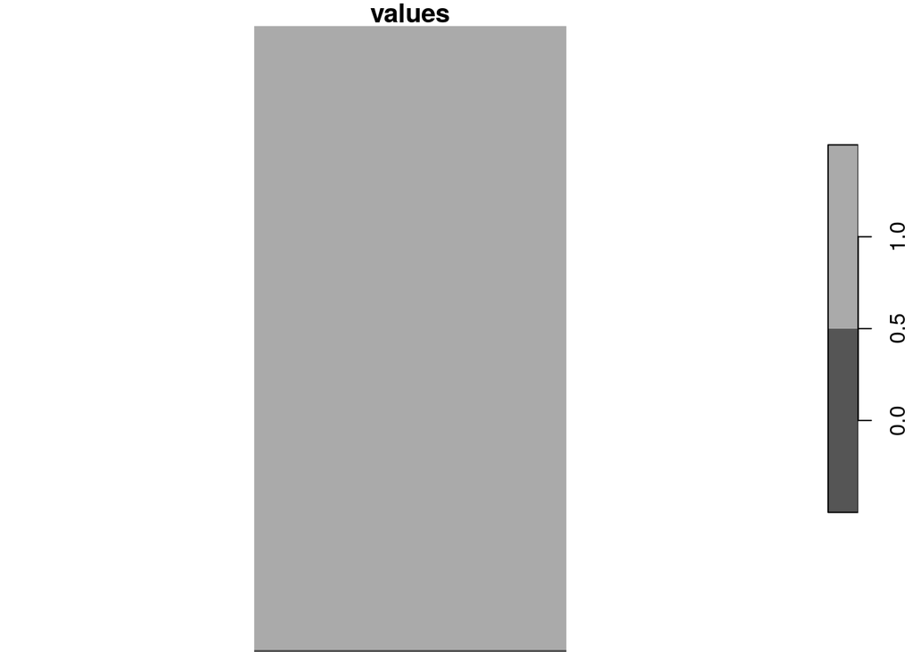

```r
grd = st_as_stars(pol)
plot(grd)
```

```r
grd
```

```
## stars object with 2 dimensions and 1 attribute
## attribute(s):
##     values
##  Min.   :0.0000
##  1st Qu.:1.0000
##  Median :1.0000
##  Mean   :0.9972
##  3rd Qu.:1.0000
##  Max.   :1.0000
## dimension(s):
##   from  to  offset    delta
## x    1 180  405957  6.18405
## y    1 361 5758871 -6.18405
##                                                       refsys point values
## x 32632...                    , +proj=utm +zone=32 +datum...    NA   NULL
## y 32632...                    , +proj=utm +zone=32 +datum...    NA   NULL
##
## x [x]
## y [y]
```

E7. Carry out a kriging using formula `pm10~1` (constant mean model), the (transformed) data, the grid, and the fitted model

```r
kr = krige(pm10~1, pm.sf_utm, grd, v.fit)
```

```
## [using ordinary kriging]
```

E8. Plot the resulting kriging predictions, and try to plot the observation (pm10) points on top of it

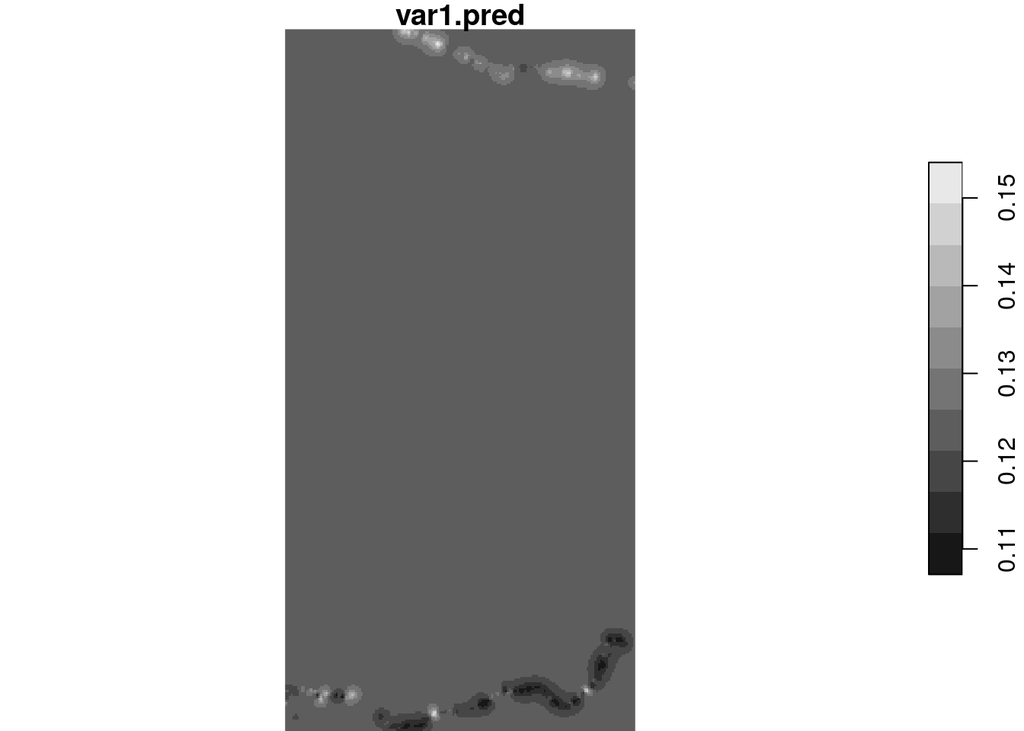

```r
plot(kr[1], breaks = "equal", reset = FALSE)
```

```r
# plot(st_geometry(pm.sf_utm), add = TRUE, col = 'red', pch = 3, cex = 0.5)
```

E9. Plot the resulting kriging variances

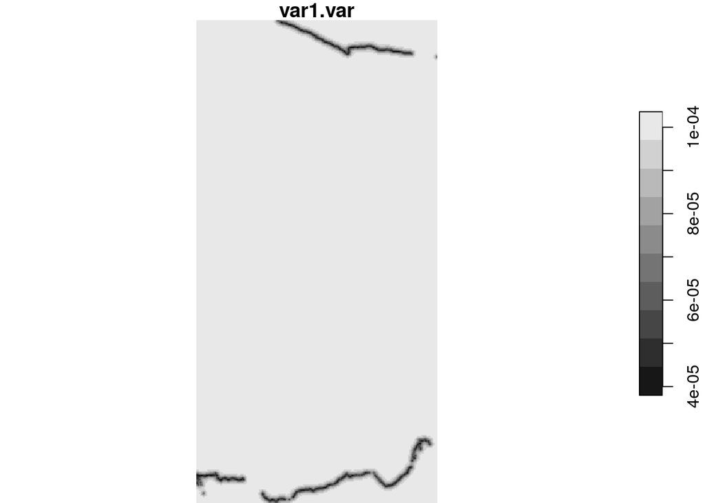

```r
plot(kr[2], breaks = "equal")
```